# Practical Machine Learning Project

Xiao Wang

April.2019

# Background

Using devices such as Jawbone Up, Nike FuelBand, and Fitbit it is now possible to collect a large amount of data about personal activity relatively inexpensively. These type of devices are part of the quantified self movement - a group of enthusiasts who take measurements about themselves regularly to improve their health, to find patterns in their behavior, or because they are tech geeks. One thing that people regularly do is quantify how much of a particular activity they do, but they rarely quantify how well they do it. In this project, I will use data from accelerometers on the belt, forearm, arm, and dumbell of 6 participants. They were asked to perform barbell lifts correctly and incorrectly in 5 different ways. The goal of this project is to predict the manner in which they did the exercise. The data come from this source: http://web.archive.org/web/20161224072740/http:/groupware.les.inf.puc-rio.br/har.

```r
library(caret)
library(rattle)
library(e1071)
library(randomForest)
library(gbm)
```

## Load the data

```r
Train <- read.csv(url("https://d396qusza40orc.cloudfront.net/predmachlearn/pml-training.csv"),header=TRUE)
Test<- read.csv(url("https://d396qusza40orc.cloudfront.net/predmachlearn/pml-testing.csv"),header=TRUE)
dim(Train)
```

```
## [1] 19622   160
```

```r
dim(Test)
```

```
## [1]  20 160
```

```r
str(Train)
```

```
## 'data.frame':    19622 obs. of  160 variables:
##  $ X                       : int  1 2 3 4 5 6 7 8 9 10 ...
##  $ user_name               : Factor w/ 6 levels "adelmo","carlitos",..: 2 2 2 2 2 2 2 2 2 2 ...
##  $ raw_timestamp_part_1    : int  1323084231 1323084231 1323084231 1323084232 1323084232 1323084232 1323084232 1323084232 1323084232 1323084232 ...
##  $ raw_timestamp_part_2    : int  788290 808298 820366 120339 196328 304277 368296 440390 484323 484434 ...
##  $ cvtd_timestamp          : Factor w/ 20 levels "02/12/2011 13:32",..: 9 9 9 9 9 9 9 9 9 9 ...
##  $ new_window              : Factor w/ 2 levels "no","yes": 1 1 1 1 1 1 1 1 1 1 ...
##  $ num_window              : int  11 11 11 12 12 12 12 12 12 12 ...
##  $ roll_belt               : num  1.41 1.41 1.42 1.48 1.48 1.45 1.42 1.42 1.43 1.45 ...
##  $ pitch_belt              : num  8.07 8.07 8.07 8.05 8.07 8.06 8.09 8.13 8.16 8.17 ...
##  $ yaw_belt                : num  -94.4 -94.4 -94.4 -94.4 -94.4 -94.4 -94.4 -94.4 -94.4 -94.4 ...
##  $ total_accel_belt        : int  3 3 3 3 3 3 3 3 3 3 ...
##  $ kurtosis_roll_belt      : Factor w/ 397 levels "","-0.016850",..: 1 1 1 1 1 1 1 1 1 1 ...
##  $ kurtosis_picth_belt     : Factor w/ 317 levels "","-0.021887",..: 1 1 1 1 1 1 1 1 1 1 ...
##  $ kurtosis_yaw_belt       : Factor w/ 2 levels "","#DIV/0!": 1 1 1 1 1 1 1 1 1 1 ...
```

[output cut: 86 more lines]

## The first 7 variables have little impact on the outcome classe. So We will exclude them from the model.

```r
Train <- Train[, -c(1:7)]
Test <- Test[, -c(1:7)]
```

From the output above, there are many variables contain NA.

## Remove the NA

```r
train<- Train[, colSums(is.na(Train)) == 0]
test <- Test[, colSums(is.na(Test)) == 0]
```

## Partioning the training set into two

```r
set.seed(1234)
inTrain1 <- createDataPartition(train$classe, p=0.7, list=FALSE)
Train1 <- train[inTrain1,]
Test1 <- train[-inTrain1,]
dim(Train1)
```

```
## [1] 13737    86
```

## Remove the variables that are near-zero-variance

```r
NZV <- nearZeroVar(Train1)
trainData <- Train1[, -NZV]
testData  <- Test1[, -NZV]
dim(trainData)
```

```
## [1] 13737    53
```

Now we have 53 columns

# Model building

In the following, we will test 3 different models:

1. classification trees
2. random forests
3. Generalized Boosted Model

# 1. Prediction with classification trees

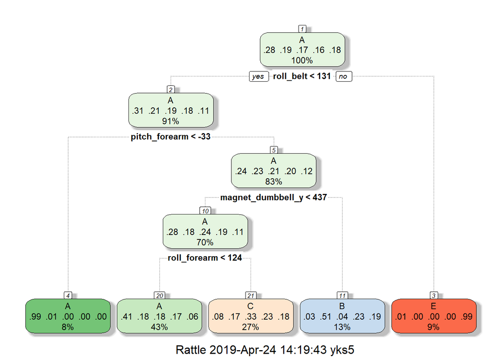

```r
trControl <- trainControl(method="cv", number=5)
model_CT <- train(classe~., data=trainData, method="rpart", trControl=trControl)
fancyRpartPlot(model_CT$finalModel)
```

## Validate the model on the testData

```r
predictTreeMod <- predict(model_CT, testData)
cmtree <- confusionMatrix(predictTreeMod, testData$classe)
cmtree
```

```
## Confusion Matrix and Statistics
##
##           Reference
## Prediction    A    B    C    D    E
##          A 1530  486  493  452  168
##          B   35  379   31  164  145
##          C  105  274  502  348  302
##          D    0    0    0    0    0
##          E    4    0    0    0  467
##
## Overall Statistics
##
##                Accuracy : 0.489
##                  95% CI : (0.4762, 0.5019)
##     No Information Rate : 0.2845
##     P-Value [Acc > NIR] : < 2.2e-16
##
##                   Kappa : 0.3311
##
##  Mcnemar's Test P-Value : NA
##
## Statistics by Class:
##
##                      Class: A Class: B Class: C Class: D Class: E
## Sensitivity            0.9140   0.3327   0.4893   0.0000  0.43161
## Specificity            0.6203   0.9210   0.7882   1.0000  0.99917
## Pos Pred Value         0.4890   0.5027   0.3279      NaN  0.99151
## Neg Pred Value         0.9478   0.8519   0.8797   0.8362  0.88641
## Prevalence             0.2845   0.1935   0.1743   0.1638  0.18386
## Detection Rate         0.2600   0.0644   0.0853   0.0000  0.07935
## Detection Prevalence   0.5317   0.1281   0.2602   0.0000  0.08003
## Balanced Accuracy      0.7671   0.6269   0.6388   0.5000  0.71539
```

## plot matrix results

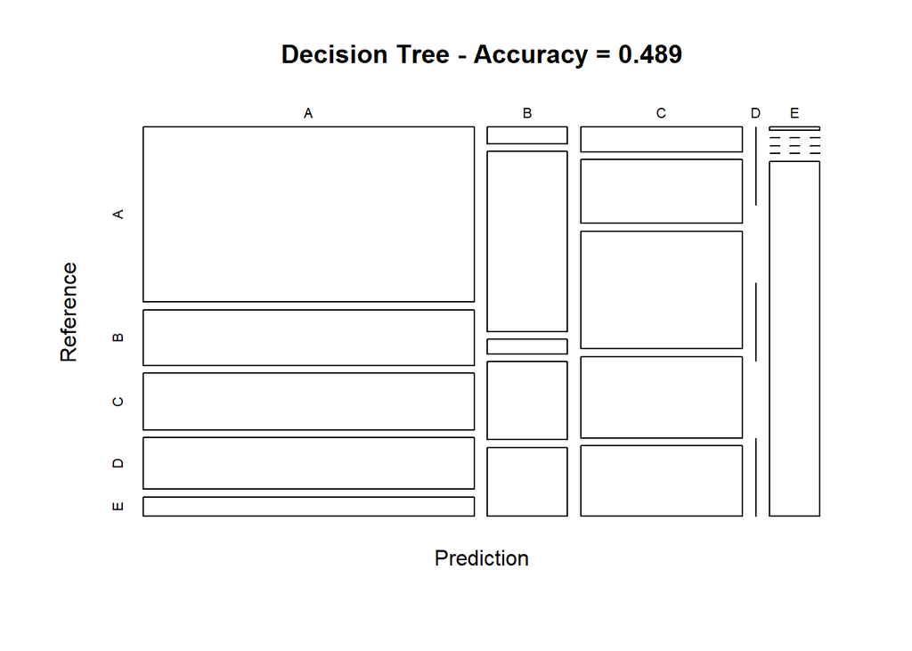

```r
plot(cmtree$table, col = cmtree$byClass,
     main = paste("Decision Tree - Accuracy =", round(cmtree$overall['Accuracy'], 4)))
```

The accuracy of this model is very low (48.9%), so this will not be a good fit.

# 2. Prediction with random forests

```r
RF <- train(classe~., data=trainData, method="rf", trControl=trControl, verbose=FALSE)
RF
```

```
## Random Forest
##
## 13737 samples
##    52 predictor
##     5 classes: 'A', 'B', 'C', 'D', 'E'
##
## No pre-processing
## Resampling: Cross-Validated (5 fold)
## Summary of sample sizes: 10990, 10988, 10989, 10991, 10990
## Resampling results across tuning parameters:
##
##   mtry  Accuracy   Kappa
##    2    0.9919912  0.9898665
##   27    0.9912639  0.9889473
##   52    0.9873328  0.9839736
##
## Accuracy was used to select the optimal model using the largest value.
## The final value used for the model was mtry = 2.
```

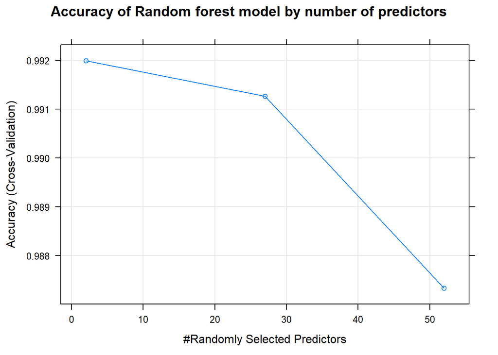

```r
plot(RF,main="Accuracy of Random forest model by number of predictors")
```

```r
trainpred <- predict(RF,newdata=trainData)
confMatRF <- confusionMatrix(trainData$classe,trainpred)
```

## Display confusion matrix and model accuracy

```r
confMatRF$table
```

```
##           Reference
## Prediction    A    B    C    D    E
##          A 3906    0    0    0    0
##          B    0 2658    0    0    0
##          C    0    0 2396    0    0
##          D    0    0    0 2252    0
##          E    0    0    0    0 2525
```

```r
confMatRF$overall[1]
```

```
## Accuracy
##        1
```

```r
names(RF$finalModel)
```

```
##  [1] "call"            "type"            "predicted"
##  [4] "err.rate"        "confusion"       "votes"
##  [7] "oob.times"       "classes"         "importance"
## [10] "importanceSD"    "localImportance" "proximity"
## [13] "ntree"           "mtry"            "forest"
## [16] "y"               "test"            "inbag"
## [19] "xNames"          "problemType"     "tuneValue"
## [22] "obsLevels"       "param"
```

```r
RF$finalModel$classes
```

```
## [1] "A" "B" "C" "D" "E"
```

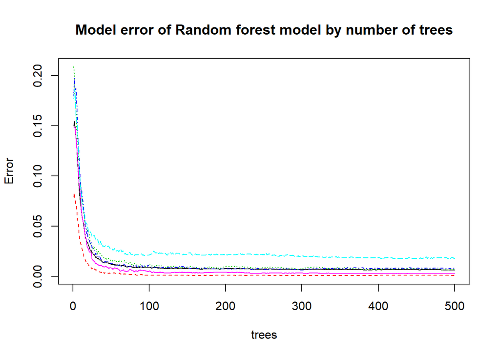

```r
plot(RF$finalModel,
     main="Model error of Random forest model by number of trees")
```

## Compute the variable importance

```r
MostImpVars <- varImp(RF)
MostImpVars
```

```
## rf variable importance
##
##   only 20 most important variables shown (out of 52)
##
##                   Overall
## roll_belt          100.00
## yaw_belt            85.50
## magnet_dumbbell_y   66.21
## magnet_dumbbell_z   65.34
## pitch_belt          61.66
## pitch_forearm       61.39
## magnet_dumbbell_x   55.08
## roll_forearm        53.85
## accel_belt_z        44.40
## magnet_belt_y       44.21
## accel_dumbbell_y    42.81
## magnet_belt_z       42.47
## roll_dumbbell       39.43
## accel_dumbbell_z    39.12
## accel_forearm_x     32.70
## roll_arm            32.67
## yaw_dumbbell        28.80
## gyros_dumbbell_y    28.77
## gyros_belt_z        28.45
## accel_dumbbell_x    27.55
```

With random forest method, we reached an accuracy of 1, indicating this is a good fit.

# 3. Generalized Boosted Model

```r
GBM <- train(classe~., data=trainData, method="gbm", trControl=trControl, verbose=FALSE)
GBM
```

```
## Stochastic Gradient Boosting
##
## 13737 samples
##    52 predictor
##     5 classes: 'A', 'B', 'C', 'D', 'E'
##
## No pre-processing
## Resampling: Cross-Validated (5 fold)
## Summary of sample sizes: 10989, 10990, 10990, 10989, 10990
## Resampling results across tuning parameters:
##
##   interaction.depth  n.trees  Accuracy   Kappa
##   1                   50      0.7494342  0.6824879
##   1                  100      0.8206296  0.7730614
##   1                  150      0.8527336  0.8136626
##   2                   50      0.8540431  0.8150996
##   2                  100      0.9064567  0.8816231
##   2                  150      0.9314983  0.9133179
##   3                   50      0.8953185  0.8674541
##   3                  100      0.9431459  0.9280579
##   3                  150      0.9606898  0.9502615
##
## Tuning parameter 'shrinkage' was held constant at a value of 0.1
##
## Tuning parameter 'n.minobsinnode' was held constant at a value of 10
## Accuracy was used to select the optimal model using the largest value.
## The final values used for the model were n.trees = 150,
##  interaction.depth = 3, shrinkage = 0.1 and n.minobsinnode = 10.
```

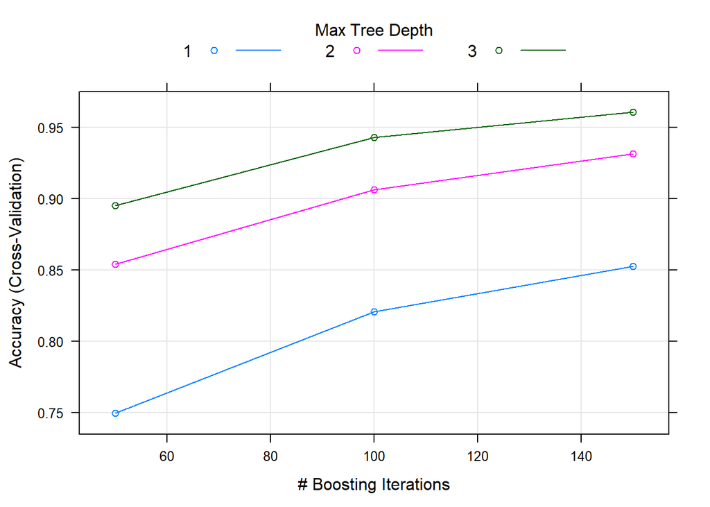

```r
plot(GBM)
```

```r
trainpred <- predict(GBM,newdata=trainData)

confMatGBM <- confusionMatrix(trainData$classe,trainpred)
confMatGBM$table
```

```
##           Reference
## Prediction    A    B    C    D    E
##          A 3872   24    7    2    1
##          B   68 2544   46    0    0
##          C    0   53 2322   19    2
##          D    0    5   59 2180    8
##          E    3   19   14   24 2465
```

```r
confMatGBM$overall[1]
```

```
##  Accuracy
## 0.9742302
```

# Conclusion

Although the accuracy from this model is very high (0.97), the random forest model is still better. We will use the random forest model to predict the values of classe for the test data set.

```r
predict(RF,newdata=test)
```

```
##  [1] B A B A A E D B A A B C B A E E A B B B
## Levels: A B C D E
```